# MA22019 - Data Visualization (Part 2)

19 February 2025

## Reminder I

- Scatter plot
- Line plot
- Histogram / Density plot
- Box / Violin plot

We create such plots in ggplot2 using the syntax

```r
ggplot( data, aes(...) ) +
  geom_...( aes(...) ) +
  labs( x=..., y=... )
```

## Reminder II

| Type of plot | geom_… |
| --- | --- |
| Scatter plot | **geom_point** |
| Line plot | **geom_line**, **geom_step** |
| Bar plot | **geom_bar**, **geom_col** |
| Histogram | **geom_histogram** |
| Box plot | **geom_boxplot** |
| Density plot | **geom_density** |
| Violin plot | **geom_violin** |

## Plan for Today

Today we will explore the remaining plot elements:

- **Coordinate system** (Sections 2.1.3 and 2.3.1)
- **Scale** and **context** (Sections 2.1.5 and 2.3.2)
- Labelling and colours (Sections 2.3.3 and 2.3.4)
- Changing the format of a data frame (Section 2.4)

This will complete Chapter 2 on data visualization.

At the end, I will make some announcements regarding Coursework 1.

## Coordinate System

## Overview

We have to decide which coordinate system is the most suitable for our analysis.

The three types we consider in this course are

- Cartesian coordinate system
- Polar coordinate system
- Geographical / spatial coordinate system

For now, we only focus on the fist two types.

The key function to switch between types is **coord_polar()**.

## Example - Wind direction at Bela Vista

We are working with:

- Hourly data from Bela Vista, Brazil, for 2017 and 2018
- Observations on wind direction and speed

Let’s explore the distribution of wind direction and its relation to wind speed.

**Which types of plot should we be using?**

## Pie charts

In ggplot2, we have to create a bar plot with polar coordinates

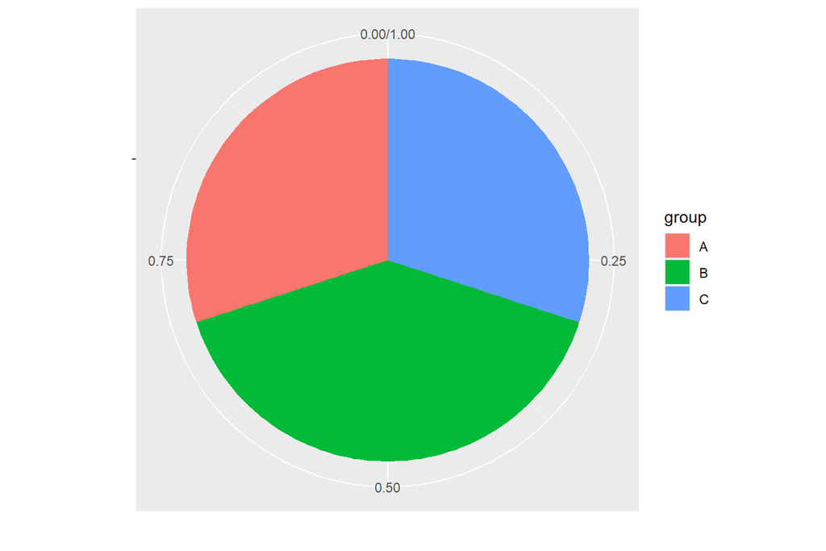

```r
df <- data.frame( "prob" = c(0.3,0.4,0.3), "group" = c("A","B","C") )
ggplot( df, aes( x="", y=prob, fill=group ) ) +
  geom_col() + coord_polar( theta="y" ) + labs( x="", y="" )
```

## Summary

There are two scenarios when a polar coordinate system may be useful to consider:

1. **Pie charts**  
   However, a bar plot may be better as it uses position and length as visual cues.
2. To visualize variables such as **direction** or **time**

Both these aspects can be achieved using **coord_polar()** in ggplot2.

Note from ggplot2 developers:  
*“Polar coordinates should be used with EXTREME caution because of the potential perceptual problems.”*

## Changing the scale

## Types of scale

We deal with three types of scale:

- **Numerical:** Speed, Age, etc.
- **Categorical:** Ratings, Sites, etc.
- **Time:** Months, Years, etc.

When we create plots, knowing the type is important when deciding on the type of plot.

## Changing numerical scales

- Plots may sometimes be dominated by a couple of data points or outliers
- Changing the scale may provide better insight
- The function **coord_trans()** is one option to change it:
  - ggplot(..) + coord_trans( x=“log10” ) logarithmic scale
  - ggplot(..) + coord_trans( x=“sqrt” ) square root scale

## Examples

Let’s look at two examples:

1. Body vs brain weight of mammals.
2. Number of followers and likes on Facebook

We will also demonstrate how to change font sizes of labels.

## Changing the colour scheme

## Overview

The ggplot2 package has a default colour scheme. Here are some of the alternatives:

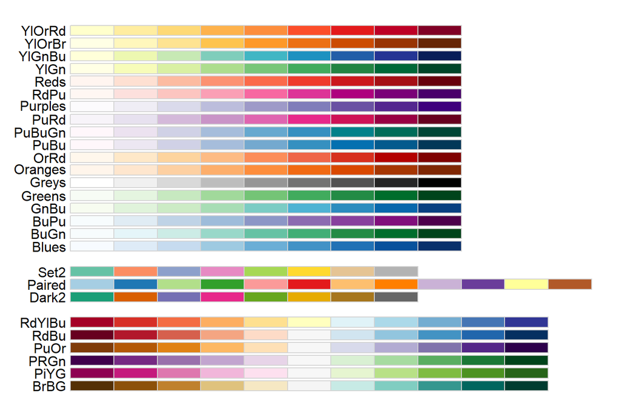

## How to use these colour schemes

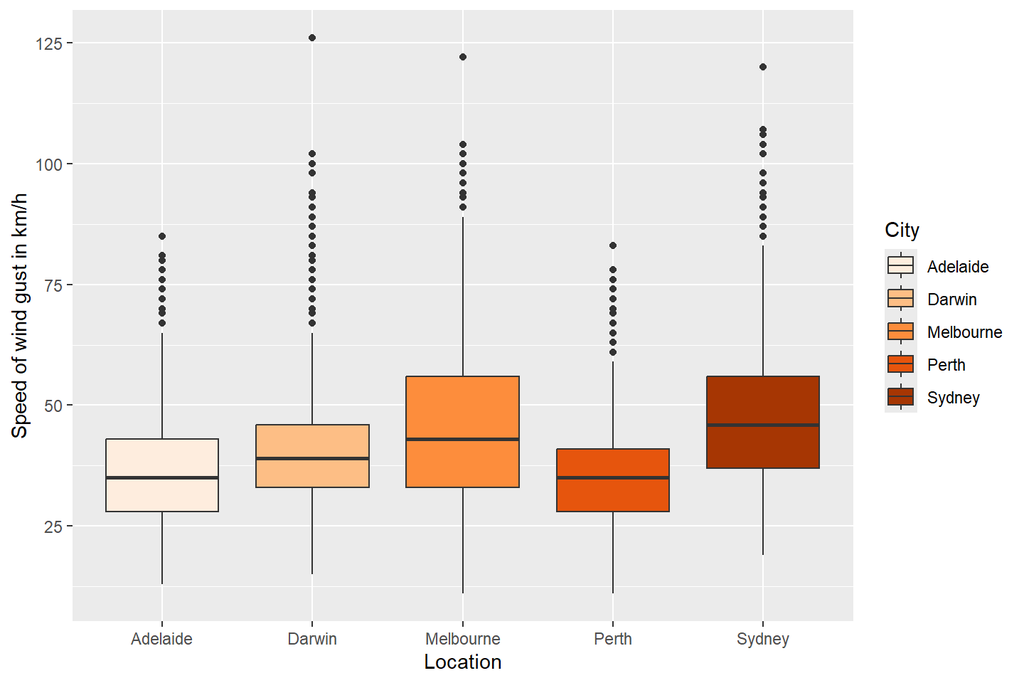

```r
AUS <- read.csv( "WeatherAustralia.csv" )
ggplot( AUS, aes( x=Location,y=WindGustSpeed ) ) +
  geom_boxplot( aes(fill=Location) ) +
  labs( y="Speed of wind gust in km/h", fill="City" ) +
  scale_fill_brewer( palette="Oranges" )
```

## Changing the data struture

## Switching data formats

- ggplot2 is based on one variable being plotted against another
- In some cases, we have to alter the data structure to create the plot we want
- The **tidyr** package provides two important functions
  - **pivot_wider()**
  - **pivot_longer()**

## Switching data formats - Example

We have monthly average temperature data for Manaus, Brazil

- Each column refers to a month
- Each row refers to a year

**For which plots is this format useful?**

**For which plots do we need to change the data format?**

## Summary

Today we

- Studied the plot elements **coordinate system**, **scale** and **context**
- Learned how to change the coordinate system and scale
- Set axis labels, font size and colour scheme
- Changed the data structure using pivot_wider() and pivot_longer
- **Remember:** Plots should also help others to make meaningful comparisons

## Coursework 1

- Released at 15:00 on Friday 21 February on Moodle
- Due at 17:00 on Friday 28 February
- Submission via Moodle only

**Support:**

- Work on it in the tutorial and in your own time
- Office Hour Monday 9:00-11:00
- Q&A session 10:15-11:05 on Wednesday 26 February
- Questions should be posted on the Padlet board